# Lab 3: Correlation and Simple Linear Modeling

Gabriel Etrata and Theo Kaufman

Exercise 1:

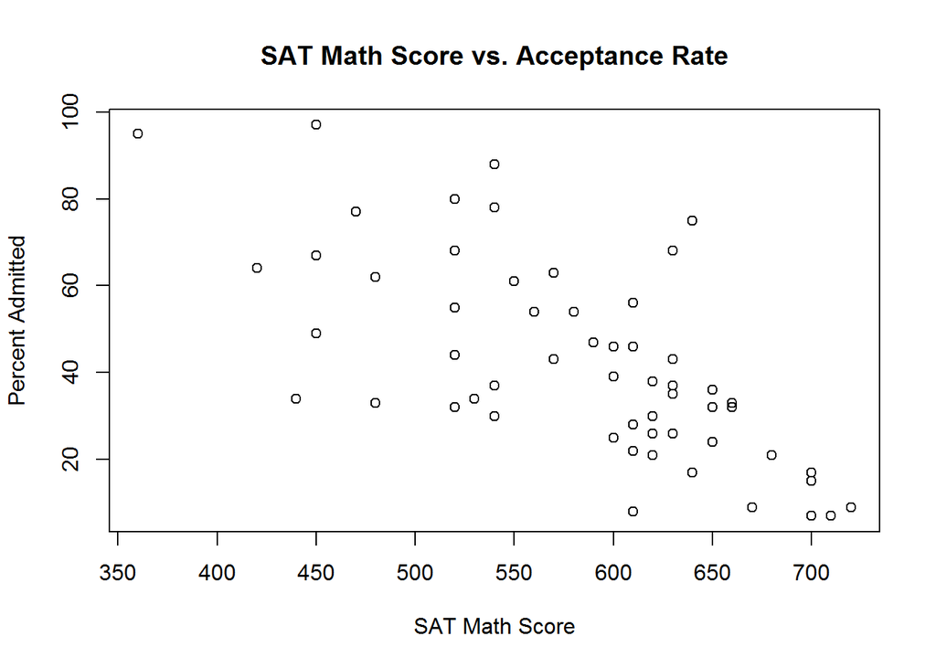

```r
plot(main="SAT Math Score vs. Acceptance Rate", sat.math.Q1, percent.admitted, xlab = "SAT Math Score", ylab = "Percent Admitted")
```

```r
cor(sat.math.Q1,percent.admitted)
```

```
## [1] -0.6834637
```

It appears that the more selective a college is, the higher their average accepted SAT Math score is. The relationship between the two variables is negative and strong.

Exercise 2:

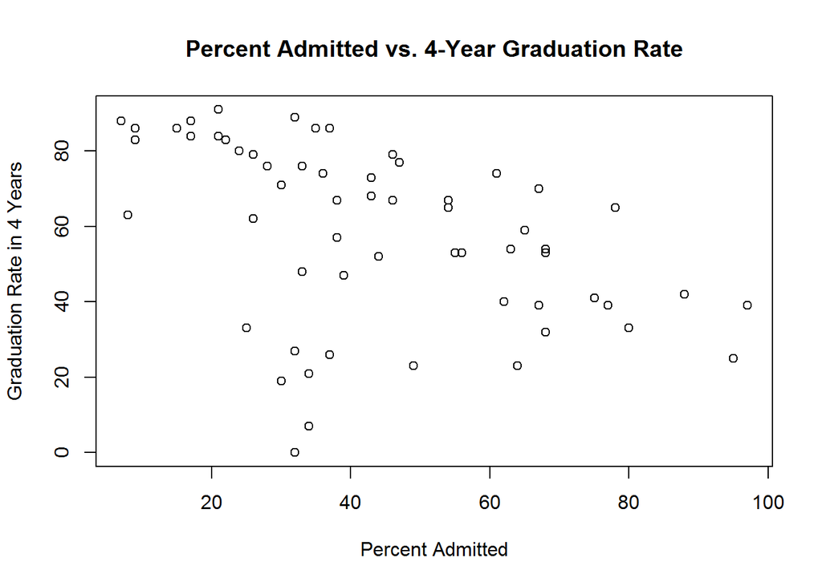

```r
plot(main="Percent Admitted vs. 4-Year Graduation Rate", percent.admitted, grad.rate.4, xlab = "Percent Admitted", ylab = "Graduation Rate in 4 Years")
```

```r
cor(percent.admitted, grad.rate.4)
```

```
## [1] -0.4637468
```

The data seems to suggest that the higher a college’s acceptance rate is, the lower their 4-year graduation rate will be. The relationship between the two variables is negative and moderately strong.

Exercise 3:

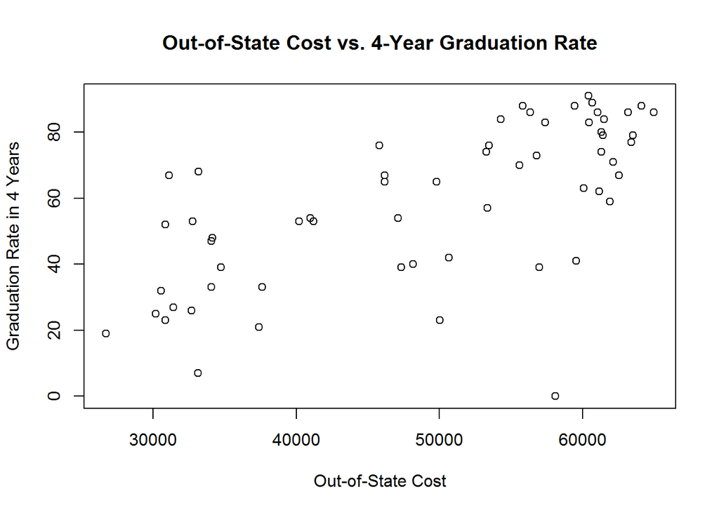

```r
plot(main = "Out-of-State Cost vs. 4-Year Graduation Rate", out.of.state, grad.rate.4, xlab = "Out-of-State Cost", ylab = "Graduation Rate in 4 Years")
```

```r
cor(out.of.state, grad.rate.4)
```

```
## [1] 0.6671544
```

The data seems to suggest that the more expensive a college is, the higher a college’s graduation rate will be. The relationship between the two variables is positive and strong.

Exercise 4:

```r
cor(lab3.data[sapply(lab3.data, is.numeric)])
```

```
##                         in.state out.of.state percent.admitted
## in.state              1.00000000   0.93015189      -0.40954581
## out.of.state          0.93015189   1.00000000      -0.36444426
## percent.admitted     -0.40954581  -0.36444426       1.00000000
## admission.yield       0.16414967   0.21120400      -0.52508035
## sat.cr.Q1             0.62223211   0.69963118      -0.70736950
## sat.math.Q1           0.51921047   0.61798339      -0.68346367
## finaid               -0.03623382  -0.10041319       0.54767604
## enrollment.undergrad -0.46115074  -0.27716343       0.22728976
## white                -0.03665966   0.07585951       0.12265870
## women                -0.07085121  -0.12524335      -0.03501822
## enrollment.total     -0.34329791  -0.15279179       0.12728101
## grad.rate.4           0.57026679   0.66715441      -0.46374684
## grad.rate.6           0.51024265   0.65714685      -0.56312100
##                      admission.yield   sat.cr.Q1 sat.math.Q1      finaid
## in.state                  0.16414967  0.62223211  0.51921047 -0.03623382
## out.of.state              0.21120400  0.69963118  0.61798339 -0.10041319
## percent.admitted         -0.52508035 -0.70736950 -0.68346367  0.54767604
## admission.yield           1.00000000  0.54570636  0.46391735 -0.38809741
## sat.cr.Q1                 0.54570636  1.00000000  0.93862240 -0.49190010
## sat.math.Q1               0.46391735  0.93862240  1.00000000 -0.51426539
## finaid                   -0.38809741 -0.49190010 -0.51426539  1.00000000
## enrollment.undergrad      0.03844224 -0.17554856 -0.02793558 -0.13700542
## white                    -0.03487695  0.25935426  0.19686347 -0.09321033
## women                    -0.03076896 -0.06212664 -0.12596269 -0.16414959
## enrollment.total          0.08204371 -0.05201209  0.09054498 -0.19878091
## grad.rate.4               0.42753837  0.77163659  0.69447743 -0.39432880
## grad.rate.6               0.48885226  0.88976594  0.87027127 -0.51232717
##                      enrollment.undergrad       white       women
## in.state                      -0.46115074 -0.03665966 -0.07085121
## out.of.state                  -0.27716343  0.07585951 -0.12524335
## percent.admitted               0.22728976  0.12265870 -0.03501822
## admission.yield                0.03844224 -0.03487695 -0.03076896
## sat.cr.Q1                     -0.17554856  0.25935426 -0.06212664
## sat.math.Q1                   -0.02793558  0.19686347 -0.12596269
## finaid                        -0.13700542 -0.09321033 -0.16414959
## enrollment.undergrad           1.00000000  0.12088348 -0.08508187
## white                          0.12088348  1.00000000  0.33384871
## women                         -0.08508187  0.33384871  1.00000000
## enrollment.total               0.96563266  0.07107328 -0.10042958
## grad.rate.4                   -0.22269391  0.32936541  0.01461678
## grad.rate.6                   -0.02785912  0.31543625 -0.06269259
##                      enrollment.total grad.rate.4 grad.rate.6
## in.state                  -0.34329791  0.57026679  0.51024265
## out.of.state              -0.15279179  0.66715441  0.65714685
## percent.admitted           0.12728101 -0.46374684 -0.56312100
## admission.yield            0.08204371  0.42753837  0.48885226
## sat.cr.Q1                 -0.05201209  0.77163659  0.88976594
## sat.math.Q1                0.09054498  0.69447743  0.87027127
## finaid                    -0.19878091 -0.39432880 -0.51232717
## enrollment.undergrad       0.96563266 -0.22269391 -0.02785912
## white                      0.07107328  0.32936541  0.31543625
## women                     -0.10042958  0.01461678 -0.06269259
## enrollment.total           1.00000000 -0.13543283  0.06299621
## grad.rate.4               -0.13543283  1.00000000  0.88216159
## grad.rate.6                0.06299621  0.88216159  1.00000000
```

```r
if(FALSE){
pairs(lab3.data[sapply(lab3.data,is.numeric)])
}
```

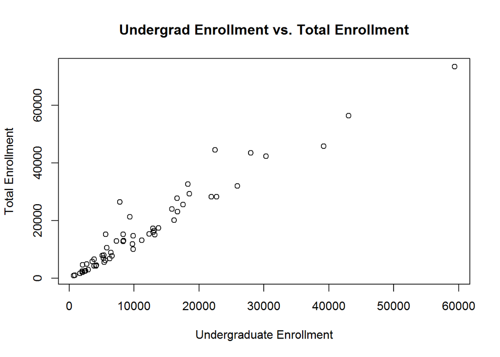

```r
plot(enrollment.undergrad, enrollment.total, main = "Undergrad Enrollment vs. Total Enrollment", xlab = "Undergraduate Enrollment", ylab = "Total Enrollment")
```

The number of undergraduate students (enrollment.undergrad) and number of all higher education students (enrollment.total) have the strongest correlation. This might be the case because the number of undergraduate students is a subset within the population of higher education students, meaning that they directly contribute to the total enrollment size.

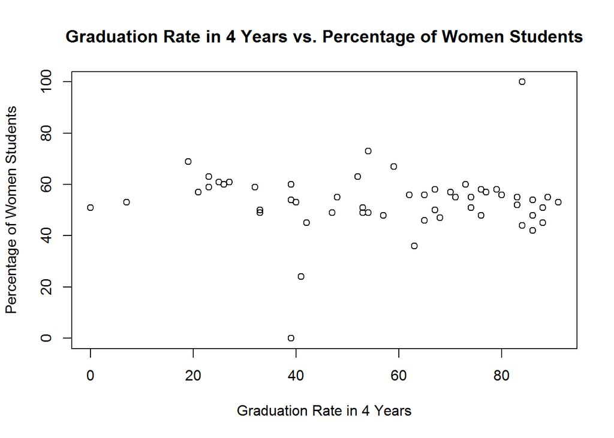

```r
plot(grad.rate.4, women, main = "Graduation Rate in 4 Years vs. Percentage of Women Students", xlab = "Graduation Rate in 4 Years", ylab = "Percentage of Women Students")
```

The graduation rate in 4 years (grad.rate.4) and percent of students who are women (women) have the weakest correlation. This might be the case because there is no strong relationship between how many women are enrolled and the overall graduation rates in 4 years of most colleges, which include both men and women. Single-sex schools are an exception in this case and should be considered as outliers.